# Used-car depreciation by brand

From bilbasen.dk listings

06 September 2026

> **Data availability.** The input file `bilbasen_data.csv` — about 9,700 adverts — is not distributed with this repository. Republishing it would be a substantial re-utilisation of bilbasen.dk’s database, protected under the EU database directive (in Denmark, ophavsretsloven § 71). What is published is the derived statistics, the ~100-row single-model extract used in section 5 with its advert-pointer and seller-location columns removed, and this rendered note, which is the record of what the full dataset showed when it was pulled. To re-run the analysis, regenerate the input with `scrape_bilbasen.py` first.

## What this does

Estimates the **average annual depreciation** of different car brands from used-car listings scraped from bilbasen.dk. For each listing we use `kontantpris` (asking cash price) and the first-registration **month/year**, and define a continuous age in years

$$\text{age} = \frac{\text{today} - \text{registration date}}{365.25},$$

dating each car to the 15th of its registration month (mid-year for the ~0.4% of listings lacking a month).

Two estimates are produced:

- **(A) Statistical (primary).** Per brand we fit a log-price model `lm(log(kontantpris) ~ age)`. The age coefficient $b$ implies a constant *proportional* loss of $1 - e^{b}$ per extra year of age. A second model adds `log(mileage)` to hold usage constant. This needs only price + year, which every listing has.
- **(B) Direct `nypris` check.** New price has no structured field on bilbasen and appears only sporadically in free text, so it is used merely as a sparse cross-check: $\text{dep} = 1 - (\text{kontantpris}/\text{nypris})^{1/\text{age}}$.

## Load & clean

```r
stopifnot(file.exists(CSV))
d <- read.csv(CSV, stringsAsFactors = FALSE, fileEncoding = "UTF-8")

# The CSV accumulates scrape snapshots (June + September 2026); a car listed in
# both appears more than once. Keep the most recent listing per external_id.
d <- d[order(d$external_id, d$scraped_at), ]
d <- d[!duplicated(d$external_id, fromLast = TRUE), ]

num <- function(x) suppressWarnings(as.numeric(x))
d$kontantpris <- num(d$kontantpris)
d$reg_year    <- num(d$reg_year)
d$reg_month   <- num(d$reg_month)
d$mileage_km  <- num(d$mileage_km)
d$nypris      <- num(d$nypris)

# Continuous age in years from the first-registration date (mid-month = day 15;
# the ~0.4% of rows without a month fall back to mid-year). This puts the right
# fraction of cars inside the first year, sharpening the first-year estimates.
mo <- ifelse(is.na(d$reg_month) | d$reg_month < 1 | d$reg_month > 12, 7, d$reg_month)
reg_date <- as.Date(sprintf("%04d-%02d-15", d$reg_year, mo))
d$age     <- as.numeric(Sys.Date() - reg_date) / 365.25
d$age     <- pmax(d$age, 1 / 365)        # floor brand-new cars at ~1 day, not 0
d$age_eff <- d$age                        # already strictly positive

# keep genuine retail cars with sane values; drop scrap/project noise
keep <- with(d,
  !is.na(kontantpris) & kontantpris >= 10000 & kontantpris <= 5e6 &
  !is.na(reg_year) & reg_year >= 1990 & reg_year <= CUR_YEAR &
  !is.na(age) & age <= 30 &
  (is.na(price_type) | price_type == "Retail"))
d <- d[keep, ]

# group on canonical make, fall back to slug
d$brand <- ifelse(is.na(d$make) | d$make == "", d$brand_slug, d$make)
```

```r
cat(sprintf("%d usable listings across %d brands.\n",
            nrow(d), length(unique(d$brand))))
```

```
## 9032 usable listings across 25 brands.
```

```r
knitr::kable(as.data.frame(table(Brand = d$brand)), col.names = c("Brand", "n"))
```

| Brand | n |
| --- | --- |
| Audi | 289 |
| BMW | 262 |
| Citroën | 286 |
| Dacia | 173 |
| Fiat | 289 |
| Ford | 263 |
| Honda | 154 |
| Hyundai | 702 |
| Kia | 290 |
| MINI | 298 |
| Mazda | 283 |
| Mercedes | 256 |
| Mitsubishi | 118 |
| Nissan | 285 |
| Opel | 276 |
| Peugeot | 284 |
| Renault | 285 |
| Seat | 293 |
| Skoda | 714 |
| Subaru | 81 |
| Suzuki | 284 |
| Tesla | 739 |
| Toyota | 701 |
| VW | 738 |
| Volvo | 689 |

## (A) Statistical annual depreciation

For every brand with enough data we fit the log-price model and translate the age coefficient into a yearly depreciation percentage.

```r
MIN_N  <- 15   # min sample to fit a brand
brands <- sort(unique(d$brand))
rows   <- list()
models <- list()   # keep each brand's age-only fit for the diagnostics appendix

for (b in brands) {
  sub <- d[d$brand == b, ]
  if (nrow(sub) < MIN_N || length(unique(sub$age)) < 3) next

  m1       <- lm(log(kontantpris) ~ age, data = sub)
  dep_rate <- 1 - exp(coef(m1)[["age"]])          # fraction lost per year
  models[[b]] <- m1

  # control for mileage where available
  sub2 <- sub[!is.na(sub$mileage_km) & sub$mileage_km > 0, ]
  dep_rate_adj <- NA_real_
  if (nrow(sub2) >= MIN_N && length(unique(sub2$age)) >= 3) {
    m2 <- lm(log(kontantpris) ~ age + log(mileage_km), data = sub2)
    dep_rate_adj <- 1 - exp(coef(m2)[["age"]])
  }

  rows[[b]] <- data.frame(
    brand          = b,
    n              = nrow(sub),
    median_price   = round(median(sub$kontantpris)),
    median_age     = round(median(sub$age), 1),
    dep_pct_yr     = round(100 * dep_rate, 1),
    dep_pct_yr_adj = round(100 * dep_rate_adj, 1),
    r2             = round(summary(m1)$r.squared, 2),
    stringsAsFactors = FALSE)
}

res <- do.call(rbind, rows)
res <- res[order(res$dep_pct_yr), ]
rownames(res) <- NULL
write.csv(res, "depreciation_by_brand.csv", row.names = FALSE)
```

**`dep_pct_yr`** = % of value lost per year of age (log-price model); **`dep_pct_yr_adj`** = same, holding mileage constant.

```r
knitr::kable(res, caption = "Annual depreciation by brand (slowest first)")
```

Annual depreciation by brand (slowest first)

| brand | n | median_price | median_age | dep_pct_yr | dep_pct_yr_adj | r2 |
| --- | --- | --- | --- | --- | --- | --- |
| Mercedes | 256 | 359850 | 2.7 | 5.5 | 6.0 | 0.23 |
| MINI | 298 | 169900 | 3.5 | 7.3 | 5.4 | 0.42 |
| Tesla | 739 | 244900 | 3.7 | 7.9 | 4.9 | 0.36 |
| Mazda | 283 | 149900 | 6.9 | 8.3 | 7.0 | 0.56 |
| BMW | 262 | 356200 | 2.8 | 9.2 | 8.4 | 0.44 |
| Subaru | 81 | 239800 | 5.3 | 9.3 | 10.0 | 0.75 |
| Volvo | 689 | 275000 | 3.4 | 9.8 | 9.7 | 0.56 |
| Fiat | 289 | 107800 | 5.1 | 10.8 | 9.8 | 0.85 |
| Audi | 289 | 369900 | 3.1 | 11.0 | 10.7 | 0.66 |
| Honda | 154 | 106950 | 10.5 | 11.1 | 9.0 | 0.69 |
| Dacia | 173 | 84900 | 7.0 | 11.2 | 11.7 | 0.62 |
| Peugeot | 284 | 127840 | 6.0 | 11.2 | 9.5 | 0.70 |
| Toyota | 701 | 129900 | 6.6 | 11.4 | 10.8 | 0.65 |
| Mitsubishi | 118 | 68300 | 9.6 | 11.5 | 10.2 | 0.51 |
| Nissan | 285 | 144900 | 6.8 | 11.8 | 11.0 | 0.70 |
| Opel | 276 | 119900 | 5.8 | 11.9 | 11.7 | 0.80 |
| Citroën | 286 | 96995 | 6.1 | 12.1 | 11.1 | 0.83 |
| Suzuki | 284 | 109700 | 7.1 | 12.5 | 11.4 | 0.81 |
| Renault | 285 | 116800 | 6.9 | 12.9 | 11.7 | 0.78 |
| VW | 738 | 239900 | 3.3 | 12.9 | 12.3 | 0.77 |
| Seat | 293 | 149800 | 6.9 | 13.8 | 14.2 | 0.63 |
| Ford | 263 | 149800 | 6.2 | 14.0 | 13.0 | 0.78 |
| Skoda | 714 | 234900 | 4.1 | 14.2 | 14.7 | 0.85 |
| Hyundai | 702 | 154900 | 4.5 | 14.6 | 14.9 | 0.80 |
| Kia | 290 | 174800 | 4.3 | 15.2 | 15.1 | 0.86 |

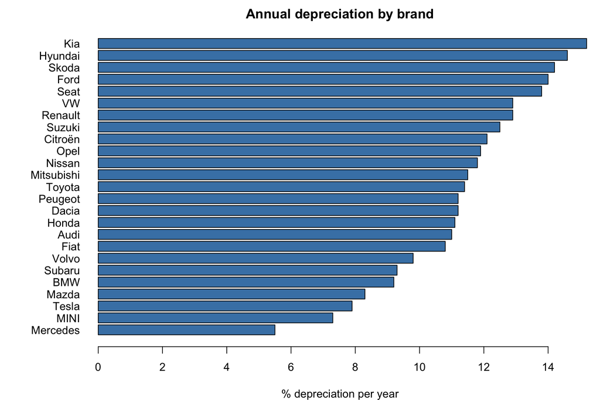

```r
op <- par(mar = c(4, 7, 2, 1))
o  <- order(res$dep_pct_yr)
barplot(res$dep_pct_yr[o], names.arg = res$brand[o], horiz = TRUE, las = 1,
        col = "steelblue", xlab = "% depreciation per year",
        main = "Annual depreciation by brand")
```

```r
par(op)
```

## (B) Direct nypris cross-check

```r
dn <- d[!is.na(d$nypris) & d$nypris > d$kontantpris & d$age >= 1, ]
cat(sprintf("%d of %d listings (%.1f%%) quote a usable nypris.\n",
            nrow(dn), nrow(d), 100 * nrow(dn) / max(nrow(d), 1)))
```

```
## 18 of 9032 listings (0.2%) quote a usable nypris.
```

```r
if (nrow(dn) >= 10) {
  dn$dep_direct <- 1 - (dn$kontantpris / dn$nypris)^(1 / dn$age_eff)
  agg <- aggregate(dep_direct ~ brand, dn, function(x) round(100 * median(x), 1))
  cnt <- aggregate(dep_direct ~ brand, dn, length)
  agg <- merge(agg, cnt, by = "brand", suffixes = c("_pct_yr", "_n"))
  names(agg) <- c("brand", "dep_pct_yr_direct", "n")
  knitr::kable(agg[order(agg$dep_pct_yr_direct), ], row.names = FALSE,
               caption = "Direct nypris-based depreciation (cross-check)")
} else {
  cat("Too few nypris values for a per-brand direct estimate (expected).\n")
}
```

Direct nypris-based depreciation (cross-check)

| brand | dep_pct_yr_direct | n |
| --- | --- | --- |
| MINI | 11.1 | 3 |
| Ford | 12.2 | 2 |
| Mercedes | 13.2 | 1 |
| Skoda | 13.2 | 1 |
| Volvo | 13.7 | 2 |
| Tesla | 14.7 | 4 |
| Opel | 16.1 | 1 |
| Audi | 19.7 | 3 |
| Fiat | 24.0 | 1 |

## (C) First-year cliff vs. ongoing annual rate

The appendix `p_curv` test rejects a single constant rate for most brands: depreciation is steeper early and flatter later. We relax the straight line with a two-segment (“broken-stick”) log model, knot at age 1:

$$\log(\text{price}) = a + \beta_1\,\underbrace{\min(\text{age},1)}_{\text{first year}}
+ \beta_2\,\underbrace{\max(\text{age}-1,0)}_{\text{later years}}.$$

So $1-e^{\beta_1}$ is the **first-year** drop and $1-e^{\beta_2}$ the **ongoing** annual rate thereafter. CIs below are **HC3 heteroscedasticity-robust** (the appendix showed plain OLS SEs are unsafe here).

```r
sp <- do.call(rbind, lapply(res$brand, function(b) {
  s <- d[d$brand == b, ]
  s$seg1 <- pmin(s$age, 1); s$seg2 <- pmax(s$age - 1, 0)
  base <- data.frame(brand = b, n = nrow(s), n_lt1y = sum(s$age < 1),
                     first_yr_pct = NA_real_, first_yr_ci = "—",
                     ongoing_pct  = res$dep_pct_yr[res$brand == b],
                     ongoing_ci   = "(see A)", stringsAsFactors = FALSE)
  if (length(unique(s$seg1)) < 2 || length(unique(s$seg2)) < 2) return(base)
  m  <- lm(log(kontantpris) ~ seg1 + seg2, data = s)
  r1 <- robust_ci(m, "seg1"); r2 <- robust_ci(m, "seg2")
  c1 <- dep_ci(r1[1], r1[2]); c2 <- dep_ci(r2[1], r2[2])
  base$first_yr_pct <- round(100 * (1 - exp(coef(m)[["seg1"]])), 1)
  base$first_yr_ci  <- sprintf("[%.1f, %.1f]", c1[1], c1[2])
  base$ongoing_pct  <- round(100 * (1 - exp(coef(m)[["seg2"]])), 1)
  base$ongoing_ci   <- sprintf("[%.1f, %.1f]", c2[1], c2[2])
  base
}))
sp <- sp[order(sp$ongoing_pct), ]
knitr::kable(sp, row.names = FALSE,
  caption = "First-year drop vs. ongoing annual rate (HC3-robust 95% CIs)")
```

First-year drop vs. ongoing annual rate (HC3-robust 95% CIs)

| brand | n | n_lt1y | first_yr_pct | first_yr_ci | ongoing_pct | ongoing_ci |
| --- | --- | --- | --- | --- | --- | --- |
| Mercedes | 256 | 49 | 36.5 | [10.9, 54.8] | 5.1 | [2.9, 7.2] |
| MINI | 298 | 3 | 90.4 | [-683950.2, 100.0] | 7.3 | [5.4, 9.1] |
| Tesla | 739 | 13 | 17.4 | [-27.7, 46.5] | 7.9 | [6.5, 9.2] |
| Mazda | 283 | 36 | 34.7 | [16.8, 48.8] | 8.0 | [6.4, 9.6] |
| BMW | 262 | 23 | 26.5 | [-52.9, 64.7] | 9.1 | [6.9, 11.4] |
| Subaru | 81 | 8 | -5.0 | [-34.5, 18.0] | 9.4 | [7.5, 11.3] |
| Volvo | 689 | 42 | 28.6 | [15.5, 39.6] | 9.7 | [8.8, 10.5] |
| Fiat | 289 | 7 | -2.2 | [-63.1, 35.9] | 10.8 | [10.1, 11.4] |
| Audi | 289 | 59 | 9.7 | [-7.5, 24.2] | 11.0 | [9.9, 12.2] |
| Dacia | 173 | 4 | 66.2 | [-307921613766607680.0, 100.0] | 11.0 | [9.4, 12.6] |
| Honda | 154 | 4 | 13.1 | [-22271.7, 99.7] | 11.1 | [9.7, 12.5] |
| Peugeot | 284 | 6 | 50.1 | [20.3, 68.8] | 11.1 | [9.3, 12.9] |
| Toyota | 701 | 60 | 24.2 | [14.4, 32.9] | 11.2 | [10.1, 12.2] |
| Mitsubishi | 118 | 0 | NA | — | 11.5 | (see A) |
| Nissan | 285 | 31 | 9.5 | [-23.9, 33.9] | 11.8 | [9.9, 13.7] |
| Opel | 276 | 3 | 28.8 | [-131.6, 78.1] | 11.9 | [11.0, 12.8] |
| Citroën | 286 | 11 | 39.0 | [16.4, 55.4] | 11.9 | [11.2, 12.5] |
| Suzuki | 284 | 7 | -10.6 | [-67.7, 27.1] | 12.5 | [11.7, 13.3] |
| Renault | 285 | 9 | 44.6 | [-29.6, 76.3] | 12.7 | [11.9, 13.6] |
| VW | 738 | 104 | 20.6 | [10.1, 29.9] | 12.7 | [11.9, 13.6] |
| Seat | 293 | 0 | NA | — | 13.8 | (see A) |
| Ford | 263 | 10 | -3.4 | [-121.4, 51.7] | 14.1 | [12.6, 15.5] |
| Skoda | 714 | 105 | 2.0 | [-3.9, 7.5] | 14.5 | [13.9, 15.1] |
| Hyundai | 702 | 83 | 3.8 | [-9.4, 15.5] | 14.8 | [14.1, 15.5] |
| Kia | 290 | 69 | 20.7 | [8.0, 31.7] | 15.0 | [13.9, 16.1] |

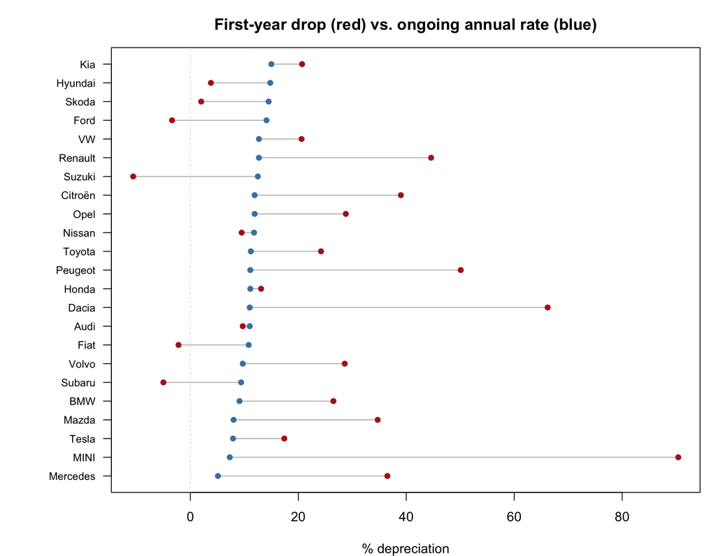

```r
sp2 <- sp[!is.na(sp$first_yr_pct), ]
sp2 <- sp2[order(sp2$ongoing_pct), ]
y   <- seq_len(nrow(sp2))
op  <- par(mar = c(4, 7, 3, 1))
plot(range(c(sp2$first_yr_pct, sp2$ongoing_pct)), c(1, nrow(sp2)), type = "n",
     yaxt = "n", xlab = "% depreciation", ylab = "",
     main = "First-year drop (red) vs. ongoing annual rate (blue)")
abline(v = 0, col = "grey85", lty = 3)
segments(sp2$ongoing_pct, y, sp2$first_yr_pct, y, col = "grey70")
points(sp2$ongoing_pct, y, pch = 16, col = "steelblue")
points(sp2$first_yr_pct, y, pch = 16, col = "firebrick")
axis(2, y, sp2$brand, las = 1, cex.axis = 0.8)
```

```r
par(op)
```

Reading this:

- **First-year > ongoing** for most brands is the cliff the diagnostics predicted.
- **`n_lt1y`** is the count of cars under one year old driving the first-year estimate; when it is small the first-year figure has a wide CI — don’t over-read.
- **Important scope caveat:** even an “age-0” listing is already a *used* car, so this first-year drop is measured *within the used market*. The genuine off-the-lot cliff (nypris → first resale) happens before age 0 and is **not** captured here — treat `first_yr_pct` as “first observed year on the used market,” not the full new-car hit.

## Price-vs-age curves

Each panel: individual listings (points) with the fitted log-price curve (red).

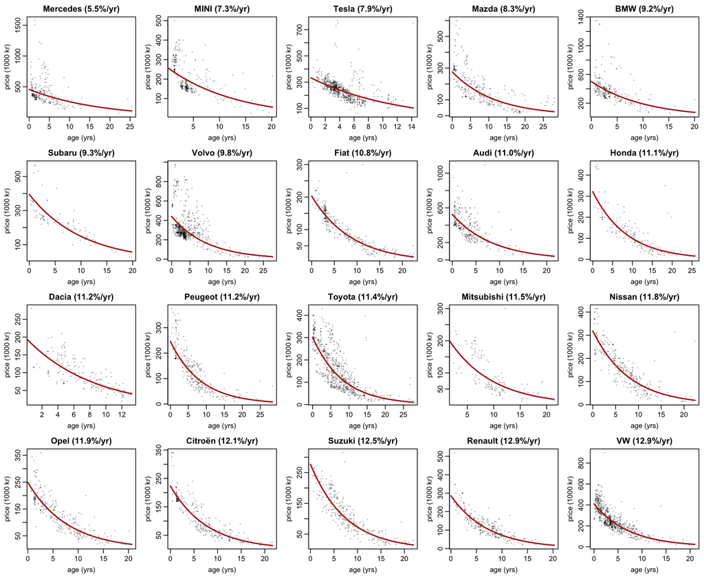

```r
op <- par(mfrow = c(4, 5), mar = c(3.2, 3.2, 2, 0.6), mgp = c(1.9, 0.6, 0))
for (b in res$brand) {
  sub <- d[d$brand == b, ]
  plot(jitter(sub$age), sub$kontantpris / 1000, pch = 16, cex = 0.4,
       col = rgb(0, 0, 0, 0.3), xlab = "age (yrs)", ylab = "price (1000 kr)",
       main = sprintf("%s (%.1f%%/yr)", b, res$dep_pct_yr[res$brand == b]))
  ag <- seq(0, max(sub$age, na.rm = TRUE), length.out = 50)
  m1 <- lm(log(kontantpris) ~ age, data = sub)
  lines(ag, exp(predict(m1, data.frame(age = ag))) / 1000,
        col = "firebrick", lwd = 2)
}
```

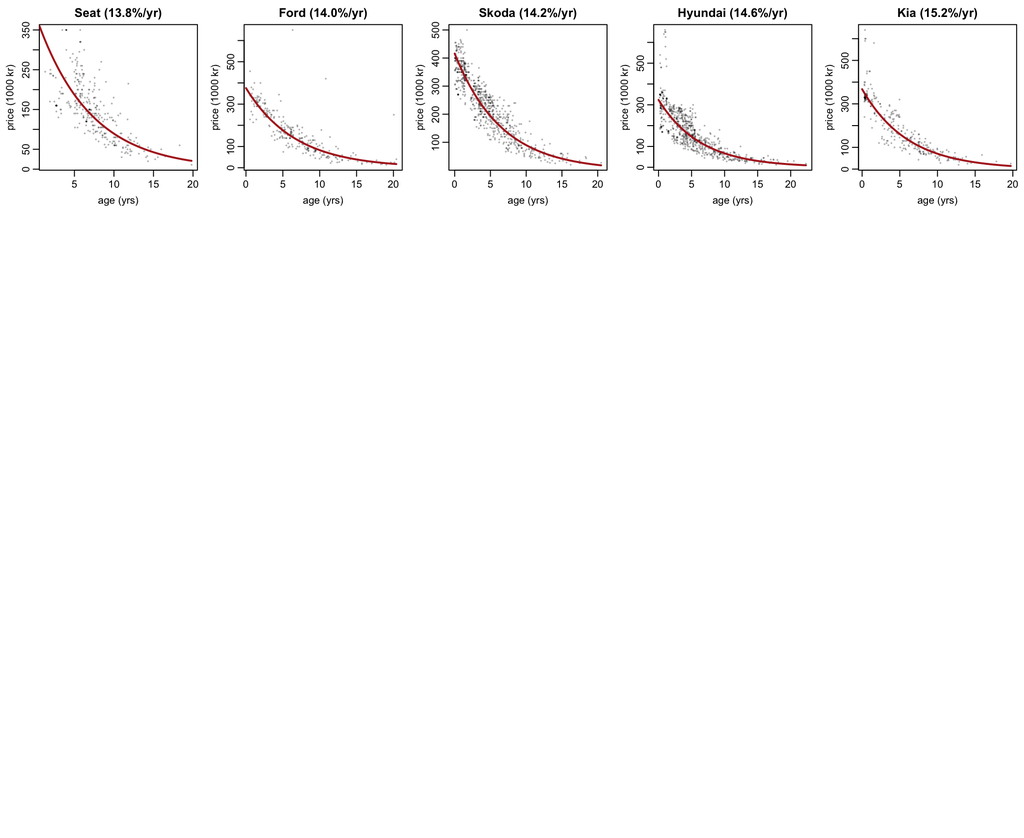

```r
par(op)
```

## (D) Case study: the same car, two badges — Solterra vs bZ4X

The **Subaru Solterra** and **Toyota bZ4X** are the jointly developed Toyota–Subaru battery-EV twins: the same platform, factory and drivetrain, sold under two brands. That makes them a natural controlled experiment — if depreciation is driven by the car, they should shed value at the same rate; if brand perception matters, they should diverge.

Data are **all** current bilbasen listings for each model, pulled separately from the brand-level dataset by `scrape_models.py` into `solterra_bz4x_data.csv`. Two notes on scope:

- The **bZ4X Touring** — the larger European wagon/SUV variant introduced in 2026 — is a *distinct model* on bilbasen (its own slug `bz4x_touring`, 12 used listings). Our pull uses the `bz4x` slug, which returns only the standard model (zero Touring cars), so the Touring is excluded by construction, as requested.
- “Touring” *does* appear in the Solterra rows — but there it is a Subaru **trim** name (`71 Touring`), not the Toyota variant — so all Solterra listings are kept.

```r
sb <- read.csv("solterra_bz4x_data.csv", stringsAsFactors = FALSE,
               fileEncoding = "UTF-8")
sb$kontantpris <- num(sb$kontantpris)
sb$reg_year    <- num(sb$reg_year)
sb$reg_month   <- num(sb$reg_month)
mo2 <- ifelse(is.na(sb$reg_month) | sb$reg_month < 1 | sb$reg_month > 12, 7,
              sb$reg_month)
sb$age <- pmax(as.numeric(Sys.Date() -
               as.Date(sprintf("%04d-%02d-15", sb$reg_year, mo2))) / 365.25, 1/365)
sb$model2 <- ifelse(sb$query == "subaru-solterra", "Solterra", "bZ4X")
sb <- sb[!is.na(sb$kontantpris) & sb$kontantpris >= 1e4 &
         !is.na(sb$age) & sb$age <= 30, ]

tab <- do.call(rbind, lapply(c("Solterra", "bZ4X"), function(mm) {
  s <- sb[sb$model2 == mm, ]
  m <- lm(log(kontantpris) ~ age, data = s)
  ci <- dep_ci(robust_ci(m, "age")[1], robust_ci(m, "age")[2])
  data.frame(model = mm, n = nrow(s),
             median_price = round(median(s$kontantpris)),
             age_range = sprintf("%.1f–%.1f", min(s$age), max(s$age)),
             dep_pct_yr = round(100 * (1 - exp(coef(m)[["age"]])), 1),
             dep_ci = sprintf("[%.1f, %.1f]", ci[1], ci[2]),
             r2 = round(summary(m)$r.squared, 2), stringsAsFactors = FALSE)
}))
knitr::kable(tab, row.names = FALSE,
  caption = "Solterra vs bZ4X: annual depreciation (HC3-robust 95% CIs)")
```

Solterra vs bZ4X: annual depreciation (HC3-robust 95% CIs)

| model | n | median_price | age_range | dep_pct_yr | dep_ci | r2 |
| --- | --- | --- | --- | --- | --- | --- |
| Solterra | 25 | 264800 | 0.3–3.5 | 10.7 | [6.9, 14.4] | 0.69 |
| bZ4X | 78 | 299900 | 0.0–4.2 | 9.0 | [7.8, 10.1] | 0.74 |

To test the difference directly, pool both models and interact brand with age (Solterra is the baseline): the `model2bZ4X` term is the price-*level* gap and the `age:model2bZ4X` term is the difference in *depreciation slope*.

```r
pooled <- lm(log(kontantpris) ~ age * model2, data = sb)
knitr::kable(round(summary(pooled)$coefficients, 4),
  caption = "Pooled model: log(kontantpris) ~ age * model (Solterra = baseline)")
```

Pooled model: log(kontantpris) ~ age * model (Solterra = baseline)

|  | Estimate | Std. Error | t value | Pr(>\|t\|) |
| --- | --- | --- | --- | --- |
| (Intercept) | 12.7459 | 0.0341 | 373.9321 | 0.0000 |
| age | -0.1132 | 0.0155 | -7.3000 | 0.0000 |
| model2bZ4X | -0.0295 | 0.0358 | -0.8256 | 0.4110 |
| age:model2bZ4X | 0.0192 | 0.0168 | 1.1456 | 0.2547 |

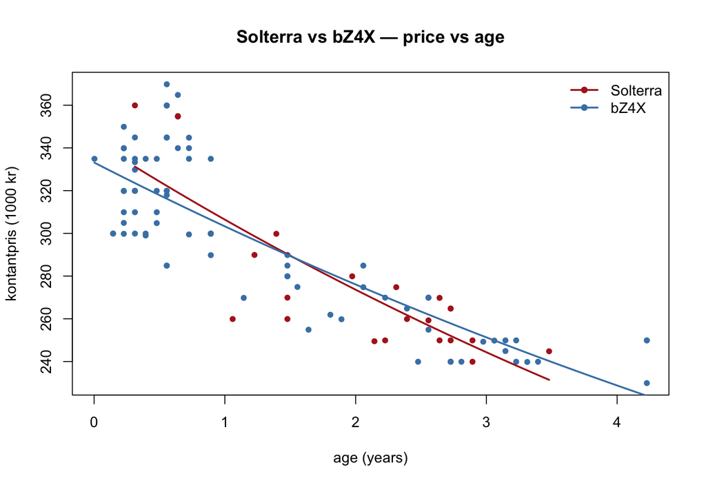

```r
cols <- c(Solterra = "firebrick", "bZ4X" = "steelblue")
plot(sb$age, sb$kontantpris / 1000, pch = 16, cex = 0.9, col = cols[sb$model2],
     xlab = "age (years)", ylab = "kontantpris (1000 kr)",
     main = "Solterra vs bZ4X — price vs age")
for (mm in c("Solterra", "bZ4X")) {
  s  <- sb[sb$model2 == mm, ]; m <- lm(log(kontantpris) ~ age, data = s)
  ag <- seq(min(s$age), max(s$age), length.out = 50)
  lines(ag, exp(predict(m, data.frame(age = ag))) / 1000, col = cols[mm], lwd = 2)
}
legend("topright", legend = c("Solterra", "bZ4X"), col = cols,
       pch = 16, lwd = 2, bty = "n")
```

**Verdict.** The two badges depreciate at **statistically indistinguishable rates** (~9–11%/yr, heavily overlapping CIs). In the pooled model neither the price-level term (`model2bZ4X`) nor the slope-difference term (`age:model2bZ4X`) comes close to significance — brand moves neither the price nor the depreciation rate once age is accounted for. For mechanically identical cars, that is the reassuring result.

## Caveats

- **Cross-sectional, not longitudinal**: different cars of different ages at one point in time, not the same car aging. Brand model-mix shifts (e.g. more EVs recently) partly confound the age signal.
- “modelår” here = **first-registration date** (month/year from bilbasen), used as a continuous age. Registration day is unknown, so we assume mid-month.
- **Asking** prices, not transaction prices; dealer stock skews newer.
- Low-price / very old outliers are filtered above to stabilise the log fit.
- **Two scrape snapshots merged.** Listings come from a June and a September 2026 scrape; cars present in both are de-duplicated to their most recent listing, but asking prices still span ~3 months of vintage. Negligible for the slopes, which depend on registration date rather than scrape date.

## Appendix: regression diagnostics

These diagnostics all refer to the **primary** age-only model `lm(log(kontantpris) ~ age)` reported in section (A) — one fit per brand. They quantify the uncertainty behind each headline rate and test the assumptions behind the log-linear form. (Base R only.)

### Diagnostics table

```r
diag <- do.call(rbind, lapply(names(models), function(b) {
  m  <- models[[b]]
  s  <- summary(m)
  bcoef <- coef(m)[["age"]]
  ci    <- confint(m, "age")                  # OLS 95% CI for slope b
  rci   <- robust_ci(m, "age")                # HC3-robust 95% CI for slope b
  # depreciation rate = 1 - e^b is decreasing in b -> swap CI ends
  dep    <- 100 * (1 - exp(bcoef))
  dep_lo <- 100 * (1 - exp(ci[2]))
  dep_hi <- 100 * (1 - exp(ci[1]))
  # functional form / curvature: significance of an added age^2 term
  mf <- model.frame(m); y <- mf[[1]]; agev <- mf[["age"]]
  p_curv <- tryCatch(
    summary(lm(y ~ agev + I(agev^2)))$coefficients["I(agev^2)", "Pr(>|t|)"],
    error = function(e) NA_real_)
  # Breusch-Pagan heteroscedasticity (manual LM = n * R^2 ~ chisq_1)
  bp   <- summary(lm(I(resid(m)^2) ~ fitted(m)))
  p_bp <- pchisq(length(resid(m)) * bp$r.squared, df = 1, lower.tail = FALSE)
  # residual normality
  p_norm <- tryCatch(shapiro.test(resid(m))$p.value, error = function(e) NA_real_)
  data.frame(
    brand      = b,
    n          = nrow(mf),
    dep_pct_yr = round(dep, 1),
    ci95       = sprintf("[%.1f, %.1f]", dep_lo, dep_hi),
    ci95_rob   = sprintf("[%.1f, %.1f]", dep_ci(rci[1], rci[2])[1],
                                         dep_ci(rci[1], rci[2])[2]),
    adj_r2     = round(s$adj.r.squared, 2),
    resid_se   = round(s$sigma, 3),
    p_curv     = signif(p_curv, 2),
    p_hetero   = signif(p_bp, 2),
    p_norm     = signif(p_norm, 2),
    stringsAsFactors = FALSE)
}))
diag <- diag[order(diag$dep_pct_yr), ]
knitr::kable(diag, row.names = FALSE,
  caption = "Per-brand diagnostics for the model log(kontantpris) ~ age")
```

Per-brand diagnostics for the model log(kontantpris) ~ age

| brand | n | dep_pct_yr | ci95 | ci95_rob | adj_r2 | resid_se | p_curv | p_hetero | p_norm |
| --- | --- | --- | --- | --- | --- | --- | --- | --- | --- |
| Mercedes | 256 | 5.5 | [4.3, 6.7] | [3.5, 7.6] | 0.23 | 0.359 | 8.3e-02 | 3.2e-03 | 0.0e+00 |
| MINI | 298 | 7.3 | [6.4, 8.3] | [5.5, 9.1] | 0.42 | 0.311 | 2.9e-05 | 0.0e+00 | 0.0e+00 |
| Tesla | 739 | 7.9 | [7.2, 8.6] | [6.5, 9.3] | 0.36 | 0.232 | 0.0e+00 | 0.0e+00 | 0.0e+00 |
| Mazda | 283 | 8.3 | [7.4, 9.1] | [6.8, 9.7] | 0.56 | 0.480 | 0.0e+00 | 0.0e+00 | 3.1e-02 |
| BMW | 262 | 9.2 | [8.0, 10.4] | [7.1, 11.4] | 0.44 | 0.342 | 2.2e-02 | 1.2e-05 | 0.0e+00 |
| Subaru | 81 | 9.3 | [8.1, 10.4] | [7.5, 11.0] | 0.75 | 0.270 | 7.0e-07 | 7.6e-03 | 3.0e-02 |
| Volvo | 689 | 9.8 | [9.2, 10.4] | [9.0, 10.6] | 0.56 | 0.360 | 0.0e+00 | 1.0e-07 | 0.0e+00 |
| Fiat | 289 | 10.8 | [10.3, 11.3] | [10.1, 11.4] | 0.85 | 0.253 | 5.2e-04 | 3.5e-05 | 0.0e+00 |
| Audi | 289 | 11.0 | [10.1, 11.9] | [10.0, 12.0] | 0.66 | 0.301 | 1.5e-01 | 9.6e-04 | 0.0e+00 |
| Honda | 154 | 11.1 | [10.0, 12.2] | [9.8, 12.5] | 0.69 | 0.446 | 2.0e-01 | 1.7e-03 | 0.0e+00 |
| Dacia | 173 | 11.2 | [9.9, 12.4] | [9.9, 12.5] | 0.62 | 0.287 | 2.7e-03 | 1.2e-01 | 2.8e-01 |
| Peugeot | 284 | 11.2 | [10.4, 12.0] | [9.4, 13.0] | 0.70 | 0.383 | 0.0e+00 | 0.0e+00 | 0.0e+00 |
| Toyota | 701 | 11.4 | [10.8, 12.0] | [10.5, 12.3] | 0.65 | 0.417 | 0.0e+00 | 0.0e+00 | 0.0e+00 |
| Mitsubishi | 118 | 11.5 | [9.5, 13.4] | [9.2, 13.6] | 0.51 | 0.470 | 1.6e-02 | 2.9e-02 | 6.2e-03 |
| Nissan | 285 | 11.8 | [11.0, 12.7] | [10.2, 13.4] | 0.70 | 0.386 | 6.5e-03 | 0.0e+00 | 0.0e+00 |
| Opel | 276 | 11.9 | [11.2, 12.6] | [11.0, 12.8] | 0.80 | 0.298 | 1.6e-01 | 1.0e-06 | 1.6e-06 |
| Citroën | 286 | 12.1 | [11.5, 12.6] | [11.4, 12.7] | 0.83 | 0.269 | 1.6e-04 | 2.0e-07 | 1.9e-03 |
| Suzuki | 284 | 12.5 | [11.8, 13.2] | [11.7, 13.3] | 0.81 | 0.319 | 1.5e-01 | 2.7e-05 | 4.7e-06 |
| Renault | 285 | 12.9 | [12.1, 13.6] | [12.0, 13.7] | 0.78 | 0.272 | 4.8e-01 | 6.7e-05 | 1.8e-02 |
| VW | 738 | 12.9 | [12.4, 13.4] | [12.1, 13.7] | 0.77 | 0.249 | 5.3e-03 | 0.0e+00 | 0.0e+00 |
| Seat | 293 | 13.8 | [12.6, 14.9] | [12.3, 15.2] | 0.63 | 0.345 | 6.8e-05 | 1.6e-02 | 1.9e-01 |
| Ford | 263 | 14.0 | [13.2, 14.8] | [12.6, 15.4] | 0.78 | 0.353 | 1.2e-02 | 2.8e-05 | 0.0e+00 |
| Skoda | 714 | 14.2 | [13.8, 14.6] | [13.7, 14.7] | 0.85 | 0.233 | 5.8e-01 | 0.0e+00 | 2.5e-06 |
| Hyundai | 702 | 14.6 | [14.1, 15.1] | [14.0, 15.2] | 0.80 | 0.316 | 1.1e-03 | 1.6e-03 | 8.9e-05 |
| Kia | 290 | 15.2 | [14.5, 15.8] | [14.4, 16.0] | 0.86 | 0.271 | 4.6e-03 | 6.0e-04 | 1.7e-04 |

How to read the columns:

- **`ci95` / `ci95_rob`** — 95% confidence interval on the annual depreciation %, from OLS and from HC3 heteroscedasticity-robust SEs respectively. Where they diverge, trust `ci95_rob` (most brands fail the `p_hetero` test below). Note these intervals are mostly *tight* even when `adj_r2` is low: with n≈290 the average slope is well-pinned; low r² just means age explains little of the within-brand price scatter (trim/spec/mileage do), not that the rate is fuzzy.
- **`adj_r2` / `resid_se`** — fit quality. `resid_se` is in log units, i.e. the typical *proportional* price scatter around the line (≈0.30 means ±30%).
- **`p_curv`** — p-value of an added `age²` term. Small values reject the constant %/yr (straight log line) assumption: real depreciation bends — the first-year cliff then a flatter tail — so the single rate is a curvature-averaged summary.
- **`p_hetero`** — Breusch–Pagan. Small values mean residual variance still depends on the price level even in logs, so the OLS standard errors (and the CI) are approximate and would tighten/widen under heteroscedasticity-robust SEs.
- **`p_norm`** — Shapiro–Wilk on residuals. Small values mean non-normal residuals (usually heavy tails / a few underpriced project cars). Slopes stay unbiased; only the exact CI/p-values are affected.

### Residuals vs fitted (one panel per brand)

Look for structure: a curved red lowess line signals the functional-form issue flagged by `p_curv`; a fanning point cloud signals the heteroscedasticity flagged by `p_hetero`. A flat line through a constant-width band is what we want.

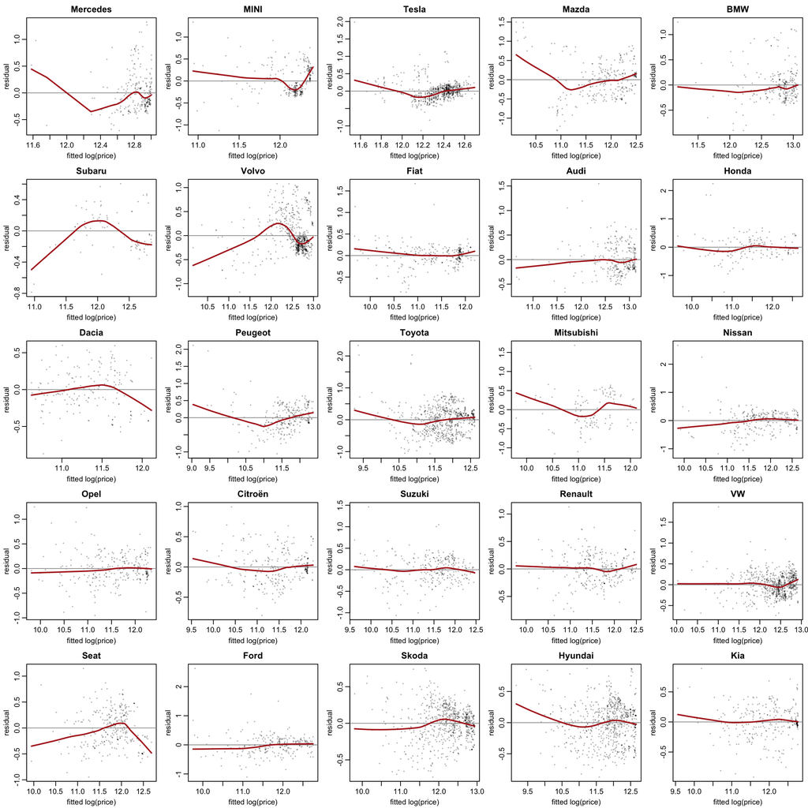

```r
op <- par(mfrow = c(5, 5), mar = c(3, 3, 2, 0.6), mgp = c(1.8, 0.6, 0))
for (b in diag$brand) {
  m <- models[[b]]
  plot(fitted(m), resid(m), pch = 16, cex = 0.4, col = rgb(0, 0, 0, 0.3),
       xlab = "fitted log(price)", ylab = "residual", main = b)
  abline(h = 0, col = "grey60")
  lines(lowess(fitted(m), resid(m)), col = "firebrick", lwd = 2)
}
```

```r
par(op)
```

### Normal Q-Q (one panel per brand)

Points on the red line ⇒ normal residuals; S-shapes / departures at the ends ⇒ heavy tails (the `p_norm` flag).

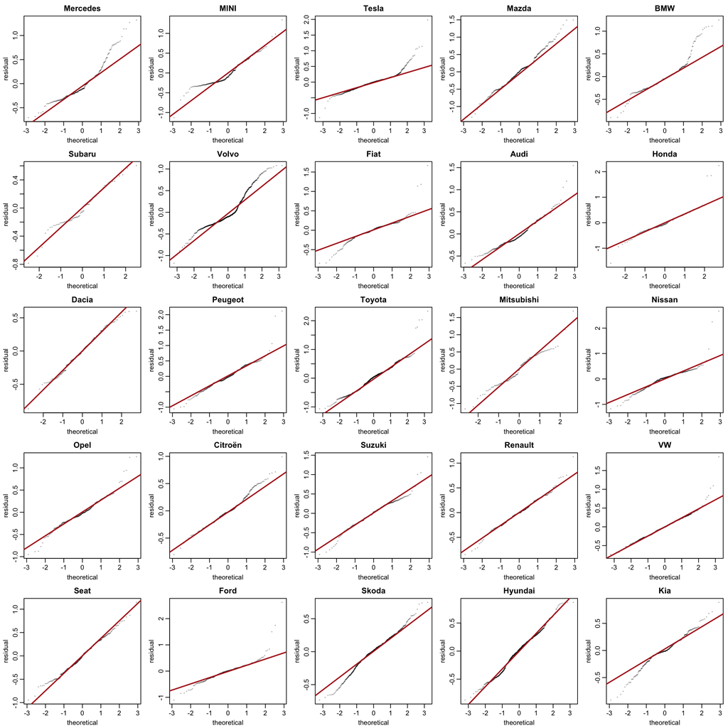

```r
op <- par(mfrow = c(5, 5), mar = c(3, 3, 2, 0.6), mgp = c(1.8, 0.6, 0))
for (b in diag$brand) {
  r <- resid(models[[b]])
  qqnorm(r, pch = 16, cex = 0.4, col = rgb(0, 0, 0, 0.3), main = b,
         xlab = "theoretical", ylab = "residual")
  qqline(r, col = "firebrick", lwd = 2)
}
```

```r
par(op)
```